# Results of Pilot coding exercise: 5 LIDD coders

## Overview

This report presents the results of the LIDD pilot coding exercise for Switzerland based on the Silagadze & Gherghina (hereafter SG) policy typology.

The following bullet points include some of the main parameters of the coding analysis as presented below.

- 30 referendum events were randomly selected)
- 5 LIDD coders submitted their pilot coding (the coders are referred to as coders, 1 to 5)
- Two measures of reliability are used. An (i) “agreement” measure and an (ii) intercoder reliability measure.
- The “agreement” measure. Agreement between a pair of coders is quite easy to understand. If coders 1 and 2 coded 100 referendums and agreed (assigned the same codes) to 60 referendums, then the level of “agreement” would be 60% (disagreement would be 40%).
- The “intercoder reliability measure.” The methodological literature uses a metric called “intercoder reliability” to measure the degree of agreement between coders rating items (referendum topics in our case). This measure is a bit more sophisticated and takes into account things like the level of agreement that could be achieved by chance (random answering). It’s called the Kappa intercoder reliability measure.
- The Kappa score can vary from `-1 to 1`. It was suggested by the author of the Kappa measure that the score could be interpreted as follows: values less than `0` indicate no agreement; and `0.01–0.20` as none to slight; `0.21–0.40` as fair; `0.41–0.60` as moderate; `0.61–0.80` as substantial; and `0.81–1.00` as almost perfect agreement.

## Agreement among LIDD coders

The table below presents the two measures across the pairs of LIDD coders. With five LIDD coders, we have 10 possible pairwise comparisons. The Kappa value in the last row is the measure of intercoder reliability among the 5 LIDD coders, which at `.29` is rather poor.

| LIDD coder pair | Agreement % | Kappa (intercoder reliability) |
| --- | --- | --- |
| c2 vs c4 | 93.3 | 0.90 |
| c1 vs c2 | 80.0 | 0.72 |
| c1 vs c4 | 80.0 | 0.72 |
| c4 vs c5 | 80.0 | 0.71 |
| c1 vs c5 | 76.7 | 0.68 |
| c2 vs c5 | 73.3 | 0.62 |
| c1 vs c3 | 66.7 | 0.58 |
| c3 vs c5 | 60.0 | 0.49 |
| c3 vs c4 | 56.7 | 0.44 |
| c2 vs c3 | 56.7 | 0.43 |
| All | 50.0 | 0.29 |

Below we check reliability by removing one coder at each iteration. Instead of five coders there are now four coders. Removing any coder is likely to boost Reliability. Below we can see the combination (in the first row) that yields the highest reliability, coders 1,2,4,5.

| LIDD coder pair | Kappa (intercoder reliability) |
| --- | --- |
| c1245 | 0.72 |
| c1234 | 0.62 |
| c1345 | 0.60 |
| c2345 | 0.59 |
| c1235 | 0.58 |

## Exploring differences among LIDD coders across items

### On which items do the 5 LIDD coders Agree?

LIDD coders were in full agreement for half the sample, 15 referendum topics. These can be seen in the table below:

| id | Code | c2d_title |
| --- | --- | --- |
| 280 | Interior Policies | Federal law of 25 September 2015 on intelligence agencies (Intelligence Agencies Act, NDG) |
| 283 | Interior Policies | Amendment of 25 September 2015 of the law on asylum |
| 316 | Interior Policies | Urgent amendment of the law on asylum |
| 333 | Interior Policies | Initiative “Protection from gun violence” |
| 334 | Economy | Citizens initiative “for equitables taxes” |
| 344 | Political/Electoral System | Federal decree of 19.12.2008 on the abandonment of the introduction of a general citizen’s initiative |
| 357 | Economy | Federal law of 23 March 2007 on the improvement of fiscal conditions concerning business and investment activities (amendment of the federal law on the taxation of private enterprise) |
| 372 | Economy | Federal decree of 19 March 2004 on the new organisation of Federal finances |
| 382 | Interior Policies | Counter-proposal by Federal Assembly of 3 October 2003 to withdrawn the citizen’s initiative “Avanti - for safe, efficient motorways” |
| 405 | Economy | Citizen’s initiative “For a capital gains tax” |
| 449 | Interior Policies | Citizen’s initiative “Switzerland without police snooping” |
| 469 | Economy | Federal decree on brake on expenditure |
| 473 | Interior Policies | Federal law on compulsory measures in the law relating to foreigners |
| 502 | Foreign Affairs | Federal decree on European Economic Area |
| 509 | Environment | Citizen’s initiative “Save our lakes and rivers” |

### On which items do the 5 LIDD coders Disagree?

LIDD coders were in disagreement for half the sample, 15 referendum topics. These can be seen in the table below, where the N_Codes refers to the number of distinct codings assigned to the referendum. For the first five rows in the table, 3 different codes were assigned to the referendum

| id | N_Codes | c2d_title |
| --- | --- | --- |
| 265 | 3 | Citizens’ initiative “For Food Sovereignty” |
| 270 | 3 | Citizens’ initiative «Yes to the abolishment of Radio and TV licence fees” |
| 310 | 3 | Amendment of the 22 March 2013 of the federal law on taxes for the use of national roads (law on national roads taxes) (motorway vignette) |
| 360 | 3 | Citizen’s initiative “For a social united health insurance” |
| 432 | 3 | Federal law on insurance for motherhood |
| 318 | 2 | Amendment of spatial planning law |
| 321 | 2 | Amendment of the law on epizootic diseases |
| 359 | 2 | Amendment of the Federal disability insurance (LAI) law |
| 375 | 2 | Amendment of 3 October 2003 to federal law on financial compensation for loss of earnings for those serving in the armed forces or performing the community service alternative, or in civil protection |
| 398 | 2 | Counter-proposal (Gold for pension funds, cantons and foundations) |
| 438 | 2 | Federal law on spatial planning, amendment of 20 March 1998 |
| 452 | 2 | Citizen’s initiative “Youth without drugs” |
| 466 | 2 | Federal law on acquisition of real estate by persons living abroad, amendment of 7 October 1994 |
| 481 | 2 | Federal air traffic law, amendment of 18 June 1993 |
| 518 | 2 | Amendment to military penal code of 5 October 1990 |

To get a better handle on the discrepancies it is easier to visualise the differences.

## Plotting divergent LIDD codes

### Items generating 3 divergent LIDD codes

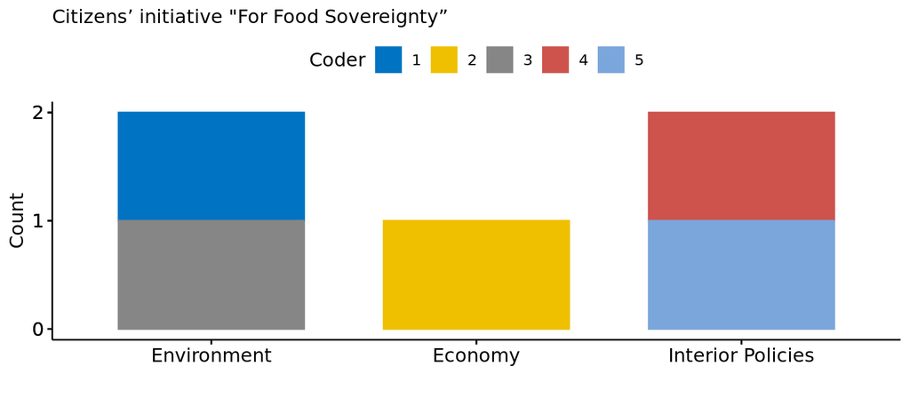

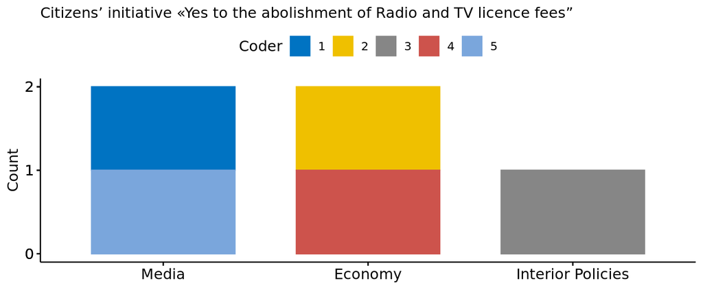

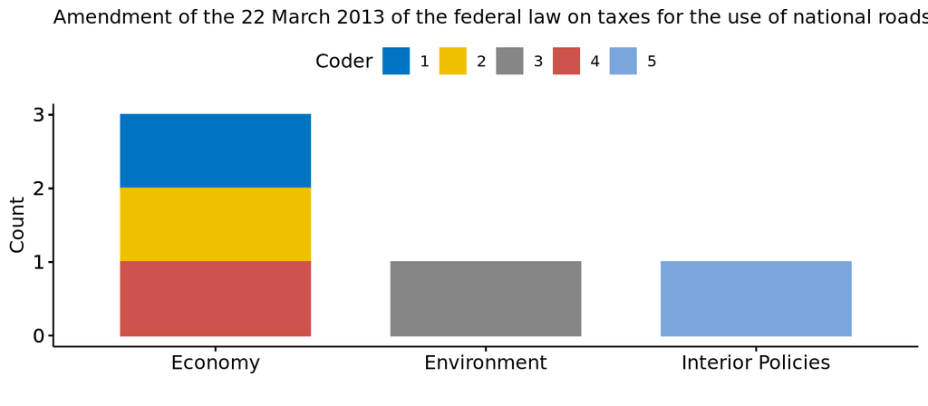

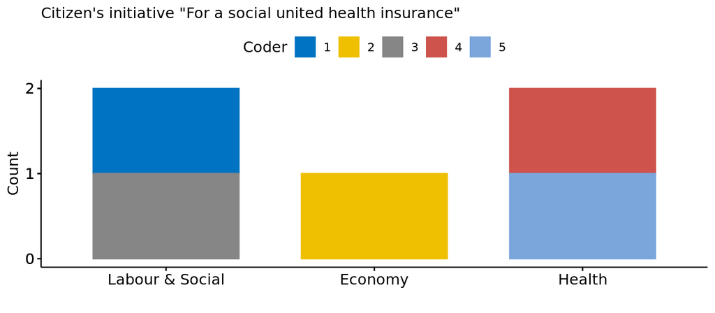

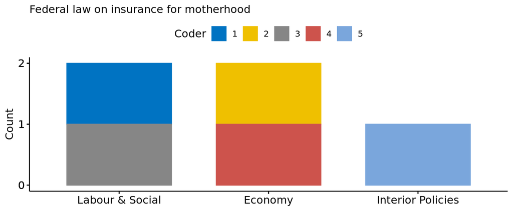

### Items generating 2 divergent LIDD codes

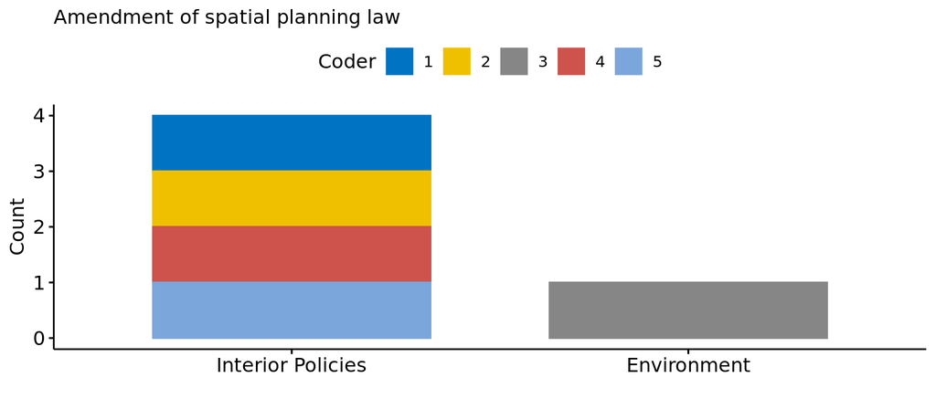

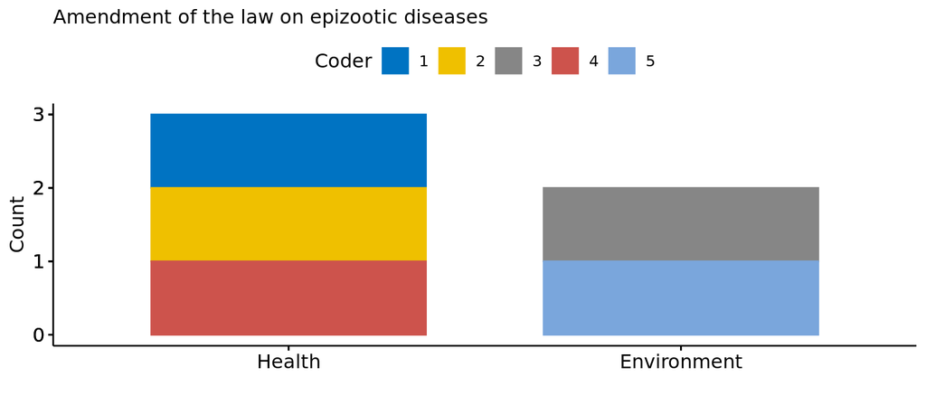

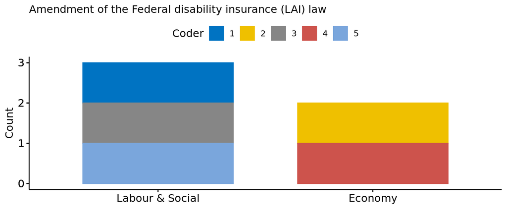

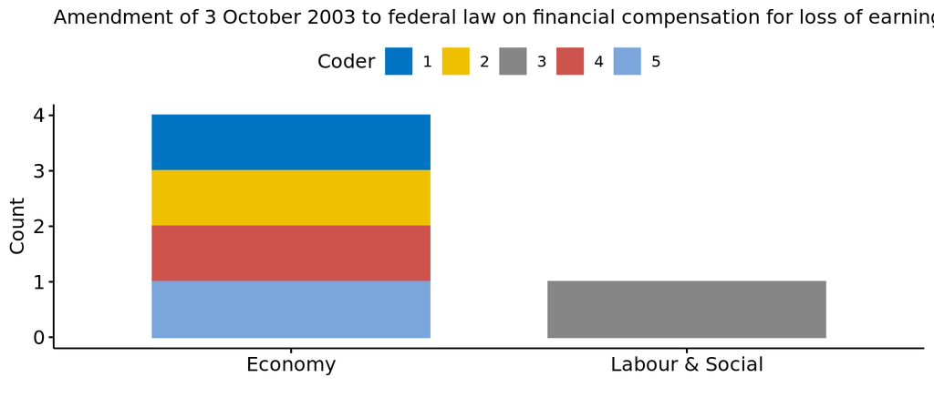

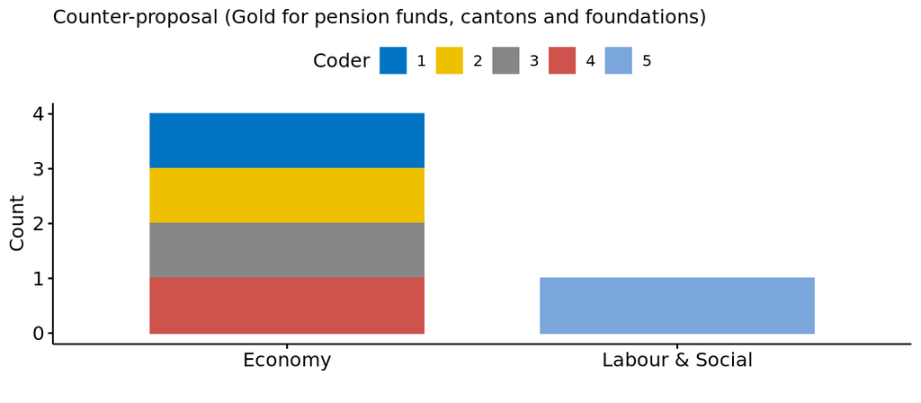

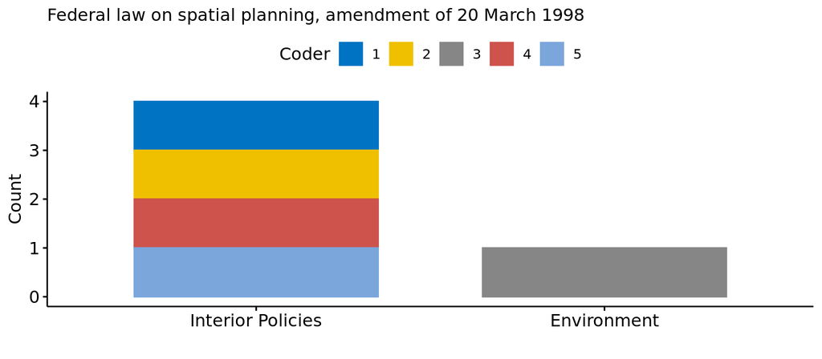

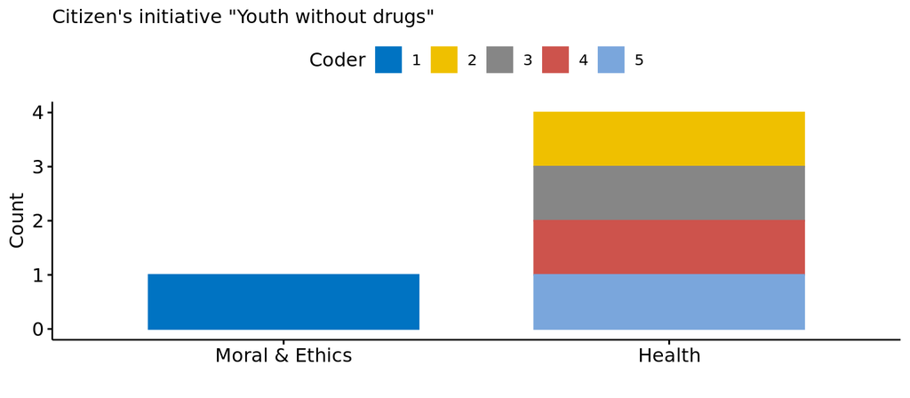

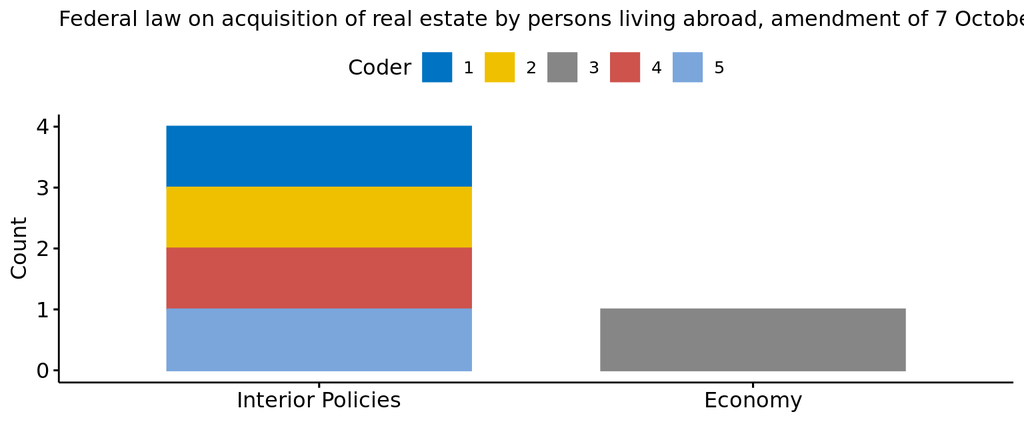

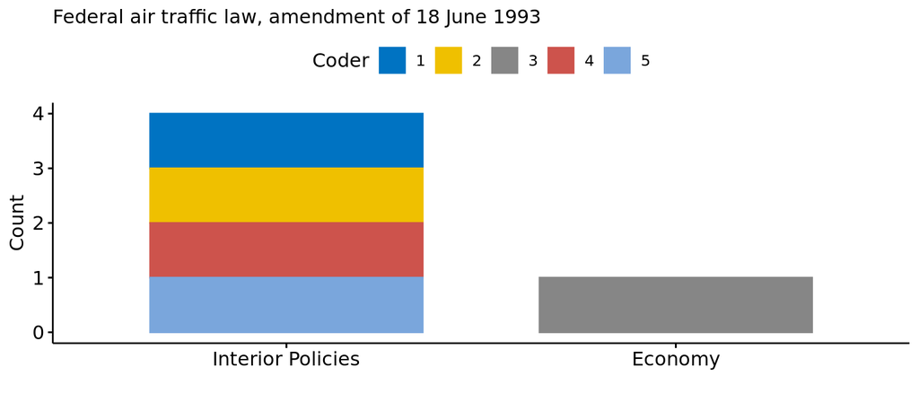

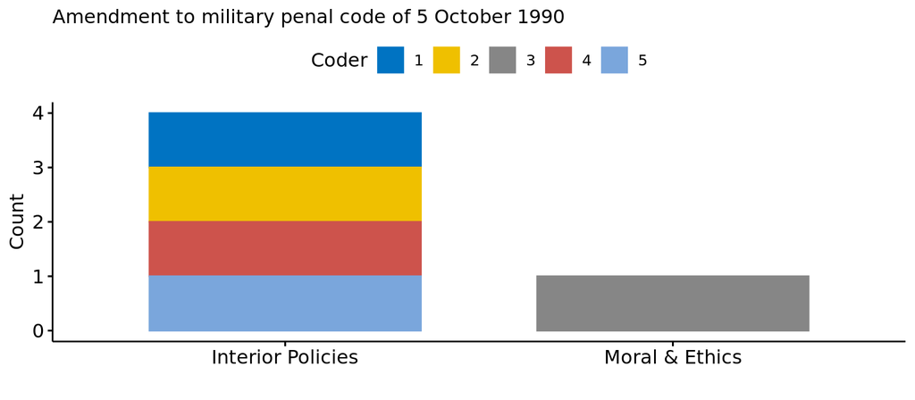

### Preliminary note on the definitions

These are comments on the definitions … for further discussion.

[output not shown]